# 消費者セグメンテーションのモデル化

## (1) 潜在クラスポアソン回帰モデル

### データ

```r
setwd("D:/R_Appendix")
Dataset <- read.csv("sec6_mixture.csv")
head(Dataset)
```

|  | pid | A | B | C | D | E | F | G | H | I | ALL | Ap | Bp | Cp | Dp | Ep | Fp | Gp | Hp | Ip | Ae | Be | Ce | De | Ee | Fe | Ge | He | Ie | … |
| --- | --- | --- | --- | --- | --- | --- | --- | --- | --- | --- | --- | --- | --- | --- | --- | --- | --- | --- | --- | --- | --- | --- | --- | --- | --- | --- | --- | --- | --- | --- |
| 1 | 100011 | 0 | 0 | 2 | 0 | 0 | 0 | 0 | 0 | 0 | 2 | 0.9979730 | 0.7780374 | 0.7309168 | 0.8776869 | 0.8360656 | 0.5986348 | 1.0000000 | 0.8198440 | 0.8481308 | 0 | 1 | 1 | 1 | 0 | 2 | 0 | 1 | 1 | … |
| 2 | 100075 | 0 | 0 | 2 | 0 | 0 | 0 | 0 | 0 | 0 | 2 | 1.0000000 | 1.0000000 | 0.5739437 | 0.9415888 | 0.9487705 | 0.7269625 | 0.9401914 | 0.9402730 | 0.9415888 | 1 | 0 | 2 | 0 | 0 | 1 | 0 | 0 | 0 | … |
| 3 | 100149 | 0 | 0 | 3 | 0 | 0 | 0 | 0 | 0 | 0 | 3 | 1.0000000 | 0.8948598 | 0.4987095 | 0.9579439 | 1.0000000 | 0.8350398 | 0.9202552 | 0.9374289 | 0.9610592 | 1 | 1 | 2 | 0 | 0 | 1 | 0 | 1 | 0 | … |
| 4 | 100301 | 0 | 1 | 2 | 0 | 0 | 0 | 0 | 0 | 0 | 3 | 0.9997820 | 0.8598131 | 0.7158431 | 0.8598131 | 0.9658470 | 0.8152121 | 0.9601276 | 0.9203640 | 0.8598131 | 0 | 1 | 1 | 1 | 0 | 0 | 0 | 0 | 0 | … |
| 5 | 100303 | 0 | 0 | 1 | 0 | 0 | 0 | 0 | 1 | 0 | 2 | 0.9876422 | 0.8769470 | 0.6846635 | 0.9778037 | 1.0000000 | 0.8583618 | 0.8122010 | 0.7568773 | 0.9304907 | 1 | 0 | 1 | 0 | 0 | 1 | 0 | 1 | 0 | … |
| 6 | 100406 | 0 | 0 | 0 | 0 | 0 | 2 | 0 | 0 | 0 | 2 | 1.0000000 | 0.6962617 | 0.7500000 | 0.7897196 | 0.9165691 | 0.6416382 | 1.0000000 | 0.9402730 | 1.0000000 | 1 | 1 | 0 | 1 | 0 | 1 | 0 | 0 | 0 | … |

**醤油カテゴリのID付POSデータ**（6.2.5節，p.90）

- pid：家計ID
- A～I：各商品の購買回数
- ALL：全商品購買回数 ($y_i$)
- Ap～Ip：各商品の購買時平均価格掛率 ($x_1 \sim x_8$，ただしApを除く)
- Ae～Ie：各商品の購買時山積み陳列実施日数
- Aa～Ia：各商品の購買時チラシ掲載日数

### モデル

（省略。教科書p.87およびp.92を参照。）

### 分析

#### 分析データの抽出・加工

```r
library(flexmix)
# 全商品購買回数（ALL）と価格（Ap～Ip）の抽出と価格の対数変換
Dataset.a <- data.frame(All = Dataset$ALL, log = log(Dataset[,13:20]))
head(Dataset.a)
```

|  | All | log.Bp | log.Cp | log.Dp | log.Ep | log.Fp | log.Gp | log.Hp | log.Ip |
| --- | --- | --- | --- | --- | --- | --- | --- | --- | --- |
| 1 | 2 | -0.2509807 | -0.3134557 | -0.13046534 | -0.17904823 | -0.5131035 | 0.00000000 | -0.19864123 | -0.16472036 |
| 2 | 2 | 0.0000000 | -0.5552240 | -0.06018663 | -0.05258835 | -0.3188804 | -0.06167182 | -0.06158498 | -0.06018663 |
| 3 | 3 | -0.1110882 | -0.6957316 | -0.04296604 | 0.00000000 | -0.1802759 | -0.08310427 | -0.06461437 | -0.03971928 |
| 4 | 3 | -0.1510403 | -0.3342943 | -0.15104026 | -0.03474985 | -0.2043070 | -0.04068910 | -0.08298598 | -0.15104026 |
| 5 | 2 | -0.1313087 | -0.3788277 | -0.02244631 | 0.00000000 | -0.1527296 | -0.20800749 | -0.27855407 | -0.07204325 |
| 6 | 2 | -0.3620297 | -0.2876821 | -0.23607730 | -0.08711783 | -0.4437306 | 0.00000000 | -0.06158498 | 0.00000000 |

#### クラスタ数1～5の一括推定

```r
set.seed(1234)
result <- initFlexmix(All ~ ., data = Dataset.a, k = 1:5,
                      model = FLXMRglm(family = "poisson"), verbose = FALSE,
                      control = list(verb = 0, classify = "auto", iter.max = 5000), nrep = 50)
print(result)
```

```
##
## Call:
## initFlexmix(All ~ ., data = Dataset.a, model = FLXMRglm(family = "poisson"),
##     k = 1:5, control = list(verb = 0, classify = "auto",
##         iter.max = 5000), nrep = 50, verbose = FALSE)
##
##   iter converged k k0     logLik      AIC      BIC      ICL
## 1    2      TRUE 1  1 -2059.6215 4137.243 4170.872 4170.872
## 2    6      TRUE 2  2 -1087.1318 2212.264 2283.258 2327.519
## 3   14      TRUE 3  3 -1005.6289 2069.258 2177.618 2310.923
## 4   34      TRUE 4  4  -958.5824 1995.165 2140.891 2365.901
## 5   29      TRUE 5  5  -937.7142 1973.428 2156.520 2448.998
```

- `set.seed(1234)`：乱数設定（括弧内の数値を変えると結果も若干変わる）
- `initFlexmix`：複数のクラスタ数を一括推定できる関数（[flexmix パッケージ](https://cran.r-project.org/web/packages/flexmix/flexmix.pdf)）
  - `All ~ .`：Dataset.aから，Allを目的変数，それ以外を説明変数と指定
  - `k = 1:5`：推定するクラスタ数として1～5を指定
- `model = FLXMRglm()` の部分を変更することで線形回帰分析などにも適用可能

#### 最良モデルの選択

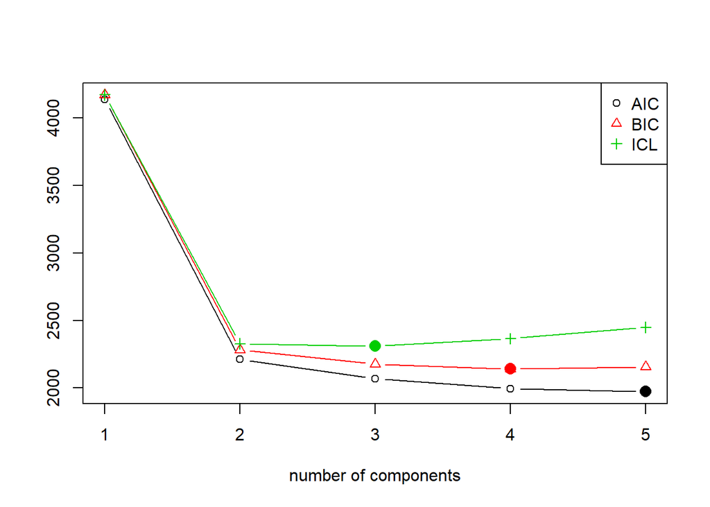

```
##
## Call:
## initFlexmix(All ~ ., data = Dataset.a, model = FLXMRglm(family = "poisson"),
##     k = 4, control = list(verb = 0, classify = "auto", iter.max = 5000),
##     nrep = 50, verbose = FALSE)
##
##        prior size post>0 ratio
## Comp.1 0.122   22    173 0.127
## Comp.2 0.364  143    251 0.570
## Comp.3 0.257   77    214 0.360
## Comp.4 0.257   68    207 0.329
##
## 'log Lik.' -958.5824 (df=39)
## AIC: 1995.165   BIC: 2140.891
```

```r
plot(result)    # モデル比較指標のプロット
best.model <- getModel(result, which = "BIC") # BICが最小のモデルを抽出
summary(best.model) # クラスタ構成比等
summary(refit(best.model))  # クラスタ別回帰係数
print(best.model@posterior$scaled) # 消費者の各クラスタ所属確率
```

（クラスタ別回帰係数と各消費者の所属クラスタの出力省略）

#### 参考文献

- [Package ‘flexmix’](https://cran.r-project.org/web/packages/flexmix/flexmix.pdf)
- [Leisch, F. (2004). Flexmix: A general framework for finite mixture models and latent glass regression in R.](https://cran.r-project.org/web/packages/flexmix/vignettes/flexmix-intro.pdf)

## (2) クラスタリング・セグメンテーション（参考）

### データ

```r
setwd("D:/R_Appendix")
df <- read.csv("data_cluster.csv", row.names = 1)
df <- data.frame(scale(df)) # scale関数でデータを平均0，標準偏差1に正規化
head(df)
```

|  | 穀類 | 魚介類 | 肉類 | 乳卵類 | 野菜海藻 | 果物 | 油脂調味料 | 菓子類 | 調理食品 | 飲料 | 酒類 |
| --- | --- | --- | --- | --- | --- | --- | --- | --- | --- | --- | --- |
| 札幌市 | -0.10552763 | 0.4266610 | -0.36744404 | -1.4428699 | -0.1713208 | -0.8297540 | -1.42158593 | -0.59508411 | -1.7059486 | -0.06054702 | 1.7534368 |
| 青森市 | -0.01185082 | 1.5916984 | -0.84822357 | -1.6800896 | 0.4446421 | 0.1742939 | -0.59071000 | -1.26447327 | -1.0595155 | 0.25414220 | 0.7833118 |
| 盛岡市 | 0.16060327 | 0.5001403 | -1.60244817 | 0.7292480 | 0.4624323 | 0.8877419 | -0.34103109 | 0.05785737 | -1.0291829 | -0.37422826 | 0.9162789 |
| 仙台市 | -1.10030878 | 1.5717912 | -0.81030319 | 1.2027888 | 1.7224835 | 1.3699179 | 0.07694990 | 1.40423885 | -0.3120399 | 1.22058685 | 1.6145473 |
| 秋田市 | -1.07605743 | 0.7946828 | -1.13503625 | -0.9516574 | 0.6295750 | 0.4575589 | 0.05290674 | -0.63573779 | -0.6960212 | -0.50345041 | 1.1571863 |
| 山形市 | 0.08547162 | 0.6305269 | -0.06408098 | 0.8897906 | 1.0858501 | 2.0727946 | 0.68588902 | 1.51130388 | 0.2195270 | 0.07613414 | 0.8119685 |

**1世帯当たり年間の品目別支出金額**（[2013年総務省家計調査](https://www.e-stat.go.jp/stat-search/files?page=1&layout=datalist&toukei=00200561&tstat=000000330001&cycle=7&year=20130&month=0&tclass1=000000330001&tclass2=000000330004&tclass3=000000330005)より）

**⇒ 各都道府県の分類および類似性を分析する**

### 分析①：k-means クラスタリング

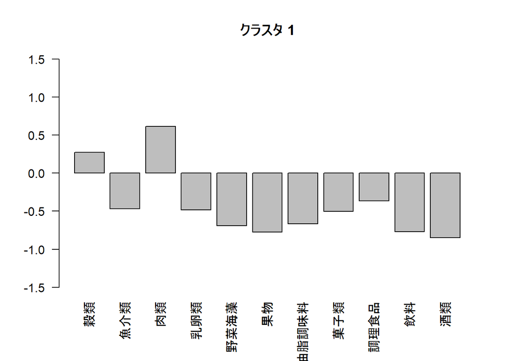

[output not shown]

```r
k <- 4  # クラスタ数の指定
result1 <- kmeans(df, centers = k)  # k-means クラスタリングの実行
print(result1$centers)  # 各クラスタの代表値
print(result1$cluster)  # 各都道府県の所属クラスタ
for (i in 1:k) {
  barplot(result1$centers[i,], las = 2, ylim = c(-1.5, 1.5), main = paste("クラスタ", i))
}
```

（クラスタ2以降の出力省略。分析結果は初期値によって異なる場合あり。）

### 分析②：階層的クラスタリング

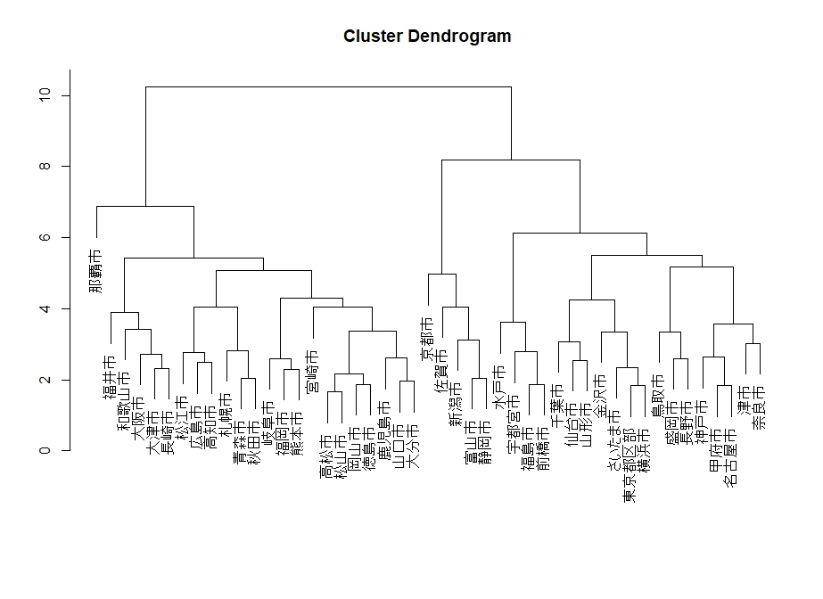

```r
df.dist <- dist(df) # 各県庁所在地間の距離を計算
result2 <- hclust(df.dist)  # クラスター分析の実行
plot(result2)
```